# Linking SDMs and forest management

Willian Vieira

Wed Jul 19 16:50:19 2017

# Introduction

Here I am using a four state transition model (STM) to understand how forest management can increase forest resilience. The model has four process-parameters that define the transition rate between the four states: Regeneration, Boreal, Temperate and Mixed (Figure 1).

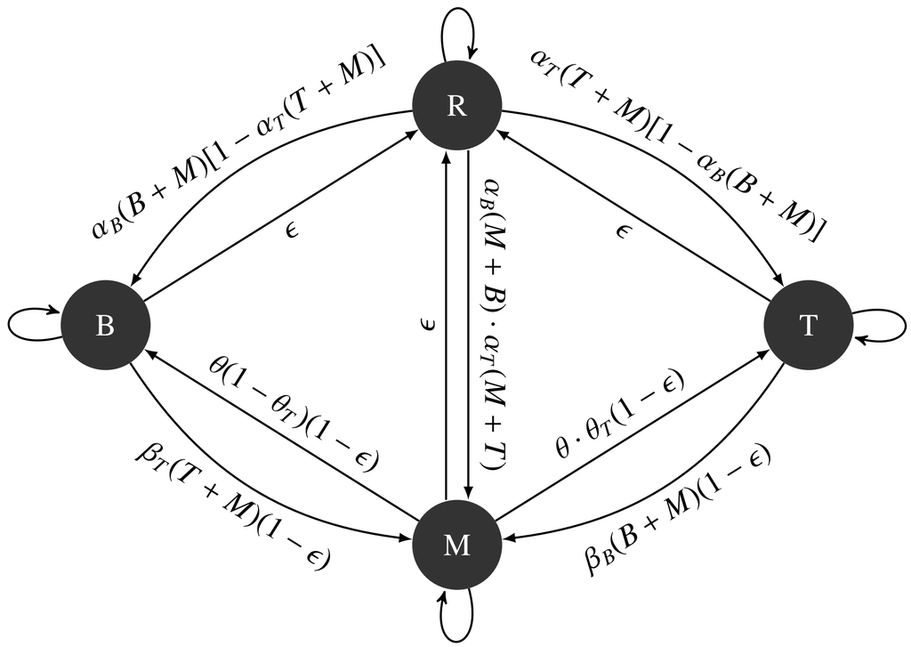

Each parameter represents a different process: $\alpha$ is the colonisation rate (R -> B, T, M), $\beta$ the succession (B, T -> M), $\theta$ the exclusion extintion (M -> B, T) and $\epsilon$ the pertubation (B, T, M -> R).

# Example of running model

```r
# call the model
source("vissault_model.R")
```

## Running the model to equilibrium

```r
# parameters
params = read.table("pars.txt", row.names = 1)

# Wrapper to collect parameters for a given set of environmental conditions
pars = get_pars(ENV1 = 0, ENV2 = 0, params, int = 3)
pars
```

```
##      alphab      alphat       betab       betat       theta      thetat
## 0.999991086 0.998278766 0.269252962 0.442427327 0.159791566 0.973086903
##         eps
## 0.009397677
```

```r
# Get the transition matrix
transition_matrix = get_matrix(ENV1 = 0, ENV2 = 0, params, int = 3)
transition_matrix$MAT
```

```
##              R            B           M           T
## R 9.906906e-01 0.0000598863 0.003873647 0.005375876
## B 3.885079e-05 0.9354824254 0.064478724 0.000000000
## M 3.896877e-03 0.0017832562 0.929843330 0.064476536
## T 5.373681e-03 0.0000000000 0.001804291 0.992822028
```

```r
# Equilibrium of the model for the specific parameters (pars)
eq = get_eq(pars)
eq
```

```
## $eq
##           B           T           M
## 0.004134084 0.571809507 0.414663890
##
## $ev
## [1] -0.1122421
```

`$eq` is the proportion of each state at equilibrium and `$ev` the eigenvalue.

## See the model behavior graphically

Starting with 25% of the proportion for each state, we can graphically see the behavior of the model until reaching equilibrium.

```r
# data frame
time <- seq(1, 50, by = 0.1)
dm2 <- data.frame(matrix(NA, nrow = length(time), ncol = 4))

# Initial condition
y = c(B = 0.25, T = 0.25, M = 0.25)
dm2[1, ] = c(y, 0.25)

# loop
for(i in 2:length(time)) {
  eq = runsteady(y = y, func = model, parms = pars, times = c(0, i))[[1]]
  eq[4] <- 1 - eq[1] - eq[2] - eq[3]
  dm2[i, ] <- eq
}
```

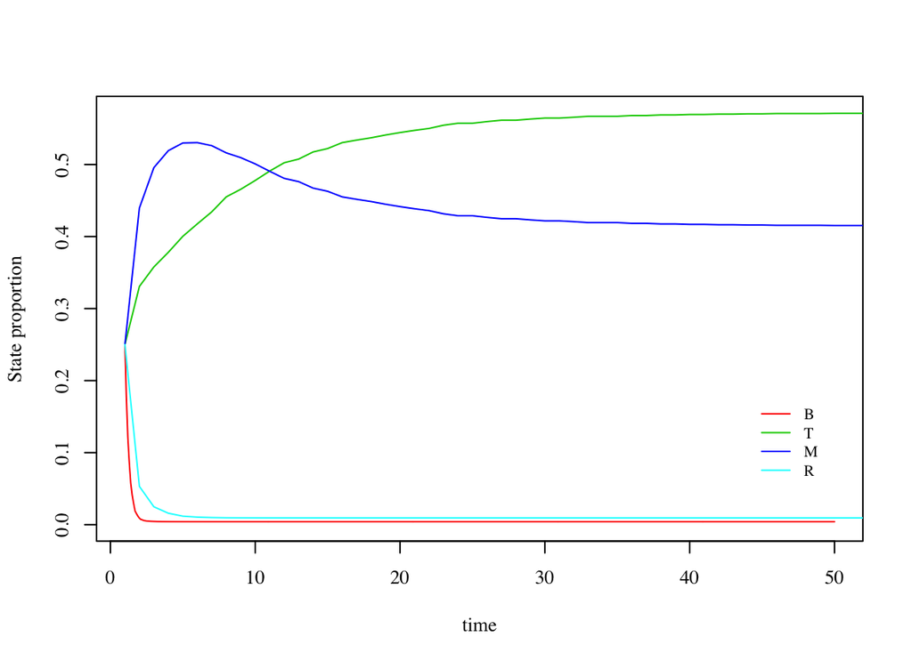

```r
# plot
par(family = 'serif', cex = 0.8)
plot(time, dm2[, 1],
     type = "l",
     ylim = c(0, max(dm2)),
     col = 2,
     ylab = "State proportion")
lines(dm2[, 2], col = 3)
lines(dm2[, 3], col = 4)
lines(dm2[, 4], col = 5)
legend(44, 0.18, c("B", "T", "M", "R"), col = 2:5, lty = 1, bty = "n", cex = 0.8)
```

# Add hypothetical disturbance

Setting up the data frame with two different environmental conditions is a way to see the behavior of the model after a disturbance. In this case, the model will start with 25% of the proportion for each state and after reaching equilibrium, the environmnetal patters will change.

```r
# Function to produce the data frame with the equilibrium proportion of each state
# based on the environmental variation.
behavior <- function(envComb1, envComb2) {
    xx <- seq(1, 40, by = 1)
    dat <- data.frame(matrix(NA, nrow = length(xx), ncol = 6))
    names(dat) <- c("ENV1", "ENV2", "B", "T", "M", "R")
    dat[c(1:20), c(1,2)] <- envComb1 #environmental 1
    dat[c(21: dim(dat)[1]), c(1,2)] <- envComb2 #environmental 2

    # Initial condition
    dat[1, c(3:6)] = c(B = 0.25, T = 0.25, M = 0.25, R = 0.25)

    # Behavior
    for(i in 2:length(xx)) {
        pars = get_pars(ENV1 = dat[i, 1],ENV2 = dat[i, 2], params, int = 3)
        y = c(B = dat[(i - 1), 3], T = dat[(i - 1), 4], M = dat[(i - 1), 5])
        eq = runsteady(y = y, func = model, parms = pars, times = c(0, i))[[1]]
      eq[4] <- 1 - eq[1] - eq[2] - eq[3]
      dat[i, c(3:6)] <- eq
    }
    return(dat)
}
```

```r
# Run the function
dat <- behavior(envComb1 = c(-.05, -.05), envComb2= c(0.05, 0.05))
```

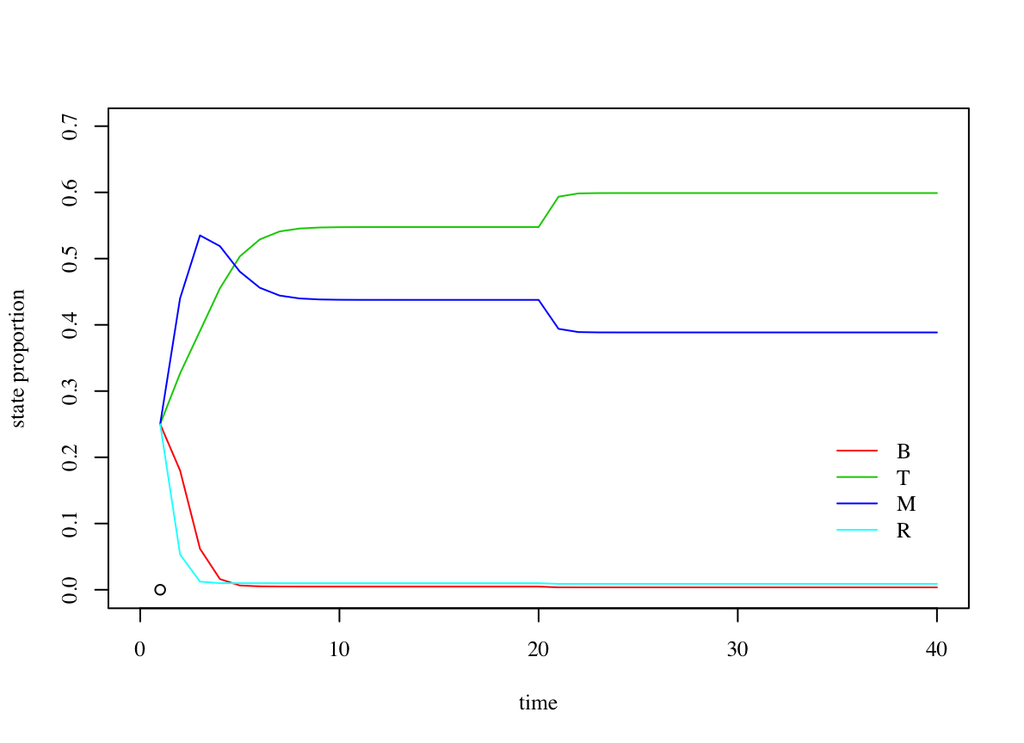

```r
# plot
par(family = 'serif', cex = 0.8)
plot(0,
     xlim = c(0, dim(dat)[1]),
     ylim = c(0, max(dat[,c(3:6)]) + 0.1),
     xlab = "time",
     ylab = "state proportion"
     )
lines(dat$B, col = 2)
lines(dat$T, col = 3)
lines(dat$M, col = 4)
lines(dat$R, col = 5)
legend(34, 0.25, c("B", "T", "M", "R"), col = 2:5, bty = "n", lty = 1)
```

# Effect of forest management on resilience

Using a numerical approach, I will set forest management into the model by changing the parameters related to each management process. For example, **plantation** can enhance colonization rate ($\alpha$), pre-commercial **thinning** can enhance both competitive exclusion ($\theta$) and succession rate ($\beta$), and **cutting** can enhance disturbance rate ($\epsilon$; Figure 2). Dotted line is the base natural process that occur without intervention.

[figure not shown]

By simply increasing the value of each parameter related to management, we can simulate the inclusion of management in the model processes (see figure above). The **recovery resilience**, or time rate in which a system returns to equilibrium after a disturbance, is measured by the largest real part of the **eigenvalue**. The eigenvalue is optained by the Jacobian matrix and a nice example can be found in this [vignette](https://cran.r-project.org/web/packages/rootSolve/vignettes/rootSolve.pdf) of the `rootSolve` package.

The choice of parameters is delicate in this kind of “*sensitivity analysis*”, then I chose to do 2 different tests in the parametric variation to simulate the response of resilience to the increasing in forest management.

`Test1` varies a specific parameter (the tested one) from 0 to 1, and the other parameters remains with the original values (fitted with field data).

## Test 1 - paramenters constant with original value

```r
# Constant value for the main parameters from 0 to 1 + original value for the other parameters
int <- 2
parSeq <- seq(0.01, 1.1, 0.05)
```

```r
# running eigenvalue to each parameter
pars = get_pars(ENV1 = 0, ENV2 = 0, params, int = int)
eql <- as.list("NA")
df <- data.frame()
for(k in 1: length(pars)) {
    pars = get_pars(ENV1 = 0, ENV2 = 0, params, int = int)
    for(j in 1: length(parSeq)) {
        pars[k] = parSeq[j]
        df[j, 1]    <- parSeq[j]
        df[j, 2] <- get_eq(pars)$ev
    }
eql[[k]] <- df
}
```

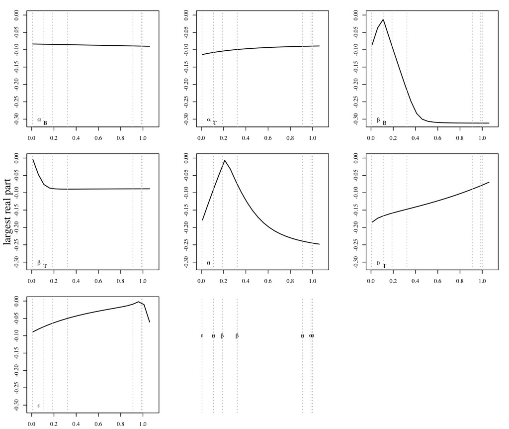

```r
# plot
Pars <- c(expression(alpha), expression(alpha), expression(beta),
          expression(beta), expression(theta), expression(theta),
          expression(epsilon))
st <- c("B", "T", "B", "T", "", "T", "")
par(family = 'serif', cex = 1.2, mfrow = c(3,3), mai = c(0.3, .5, .2, .2))
for(i in 1:7) {
    plot(eql[[i]], type = "l", lwd = 1.5, xlab = "", ylab = "", ylim = c(-.31,0), xlim = c(0, 1.1))
  abline(v = get_pars(ENV1 = 0, ENV2 = 0, params, int = int), col = "gray", lty = 3, cex = 0.8)
  if(i == 4) mtext(side = 2, "largest real part", line = 2.1, cex = 1.2)
  legend("bottomleft", Pars[i], bty = "n")
  legend(0.01, -.29, st[i], bty = "n")
}
plot(c(0, 1.1), c(-.31,0), ann = FALSE, axes = FALSE, type = "n")
abline(v = get_pars(ENV1 = 0, ENV2 = 0, params, int = int), col = "gray", lty = 3, cex = 0.8)
text(x = get_pars(ENV1 = 0, ENV2 = 0, params, int = int), y = -0.1, Pars)
```

### Interaction between parameters

Some practices can change more than a parameter, so here I want to see the interaction between these parameters influenced by the same practices. The follow function can generate a plot to visualize the interaction between $\alpha$ Boreal and $\alpha$ Temperate, $\beta$ Boreal and $\beta$ Temperate and $\theta$ and $\theta$ Temperate.

```r
# function to generate the plot interaction between parameters
parInt <- function(Par1, Par2, namePar1, namePar2) {

    # parameter variation
    int <- 2
    par1 <- seq(0.01, 0.99, 0.05)
    par2 <- seq(0.01, 0.99, 0.05)

    # all possible combination
    BT <- expand.grid(p1 = par1, p2 = par2)

    # get eigenvalue for each combination
    for(i in 1:dim(BT)[1]) {
      pars = get_pars(ENV1 = 0, ENV2 = 0, params, int = int)
      pars[c(Par1, Par2)] <- c(BT$p1[i], BT$p2[i])
      BT[i, 3] <- get_eq(pars)$ev
    }

    # setting eigenvalue dependence color
    rbPal <- colorRampPalette(c('red','blue'))
    BT$Col <- rbPal(20)[as.numeric(cut(BT$V3,breaks = 15))]

    # plot
    library(grDevices)
    par(family = "serif", cex = 0.8)
    layout(matrix(1: 2, ncol = 2), width = c(2, 1), height = c(1, 1))
    plot(BT$p1, BT$p2, pch = 15, cex = 2.9, col = BT$Col, xlab = namePar1, ylab = namePar2)

    # legend
    legend_image <- as.raster(matrix(rbPal(12), ncol=1))
    plot(c(0, 2),c(0, min(BT$V3)), type = 'n', axes = F, xlab = '', ylab = '', main = 'eigenvalue')
    text(x = 1, y = seq(max(BT$V3), min(BT$V3), l = 5), labels=round(seq(min(BT$V3), max(BT$V3),l=5),3))
    rasterImage(legend_image, min(BT$V3), min(BT$V3), 0, 0)
}
```

**$\alpha$B and $\alpha$T interaction**

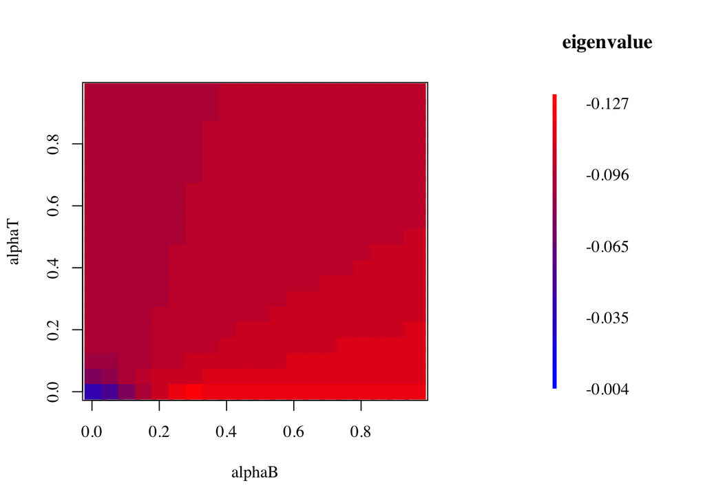

```r
# call function
parInt(1, 2, "alphaB", "alphaT")
```

**$\beta$B and $\beta$T interaction**

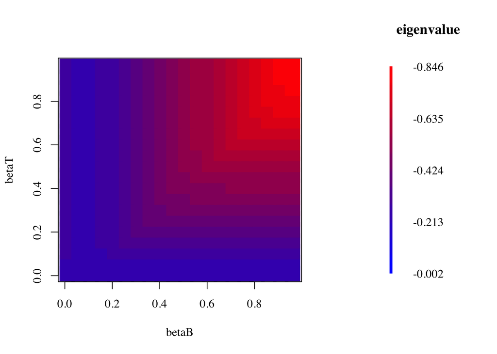

```r
# call function
parInt(3, 4, "betaB", "betaT")
```

**$\theta$ and $\theta$T interaction**

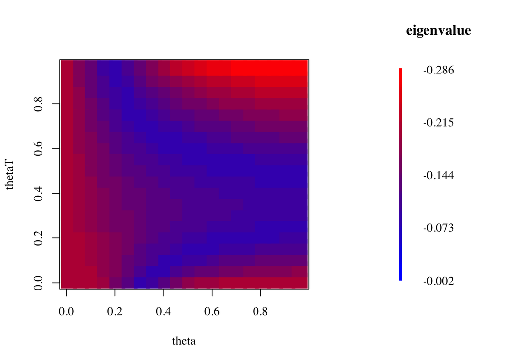

```r
# call function
parInt(5, 6, "theta", "thetaT")
```

## Test 2 - parameters constant with the same value

```r
# Constant value for all parameters from 0 to 1
int <- 2
parSeq <- seq(0.01, 0.99, 0.05)
constPar <- c(0.2, 0.4, 0.6, 0.8) #Constant value of all other parameters
```

```r
# running eigenvalue to each parameter
pars = get_pars(ENV1 = 0, ENV2 = 0, params, int = int)
eql1 <- as.list("NA")
df <- data.frame()
for(k in 1: length(pars)) {
    pars = get_pars(ENV1 = 0, ENV2 = 0, params, int = int)
  for(l in 1: length(constPar)) {
    pars[-k] <- constPar[l]
    for(j in 1: length(parSeq)) {
        pars[k] = parSeq[j]
        df[j, 1]    <- parSeq[j]
        df[j, l + 1] <- get_eq(pars)$ev
     }
  }
eql1[[k]] <- df
}
```

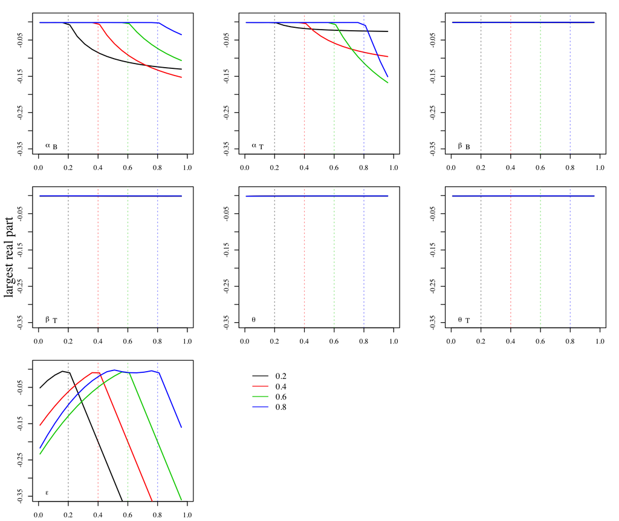

```r
# plot
source("/Users/wvieira/GitHub/NativeFunctions/addTransColor.R") #get transparance function
Pars <- c(expression(alpha), expression(alpha), expression(beta),
          expression(beta), expression(theta), expression(theta),
          expression(epsilon))
st <- c("B", "T", "B", "T", "", "T", "")
par(family = 'serif', cex = 1.2, mfrow = c(3,3), mai = c(0.3, .5, .2, .2))
for(i in 1:7) {
    plot(0, type = "n", lwd = 1.5, xlab = "", ylab = "", xlim = c(0, 1), ylim = c(-0.35, 0.01))
  if(i == 4) mtext(side = 2, "largest real part", line = 2.1, cex = 1.2)
  legend("bottomleft", Pars[i], bty = "n")
  legend(0.01, -.32, st[i], bty = "n")
      points(eql1[[i]]$V1, eql1[[i]]$V2, type = "l", lwd = 1.5)
      points(eql1[[i]]$V1, eql1[[i]]$V3, type = "l", lwd = 1.5, col = 2)
      points(eql1[[i]]$V1, eql1[[i]]$V4, type = "l", lwd = 1.5, col = 3)
      points(eql1[[i]]$V1, eql1[[i]]$V5, type = "l", lwd = 1.5, col = 4)
    #add vertical lines
    for(j in 1:4) abline(v = constPar[j], col = addTrans(j, 120), lty = 3)
}
#add second legend
plot(c(-1, 1), c(-1, 1), ann = FALSE, axes = FALSE, type = "n")
legend(-1, 1, constPar, lty = 1, col = c(1:4), bty = "n", cex = 1.2)
```

## Testing all parameters combination

Now we saw the variation of each parameter, we want to see every parameter changing with each other to test all combinations of parameters. The sensitivity analysis helps us to test some of the following questions:

- How is the relation between input and outputs of the model?
- For what parameter are the outputs varying more?
- Can we reduce uncertainty and hence increase robustness?

All these questions will then be guided to measure the impact of forest management on the parameters (based in figure 2).

Using the `expand.grid` function, the parameters variation goes from 0.09 to 0.99:

```r
# parameters
parm <- seq(0.09, 0.99, 0.15)

# all possible combination
sim <- expand.grid(alphab = parm,
                   alphat = parm,
                   betab = parm,
                   betat = parm,
                   theta = parm,
                   thetat = parm,
                   eps = parm)
```

```r
dim(sim)
```

```
## [1] 823543      7
```

```r
# get eigenvalue for each variation (time ~ 29 hrs in one core):
# system.time(for(i in 1: dim(sim)[1]) {
#   eq <- get_eq(sim[i, ])
#   sim[i, 8] <- eq$ev
#   sim[i, 9] <- eq$eq[1] #eq B
#   sim[i, 10] <- eq$eq[2] #eq T
#   sim[i, 11] <- eq$eq[3] #eq M
#   cat(100*i/dim(sim)[1], "%", "\r")
# })
```

```r
# save the output
# save(sim, file = "data/ev.RData")
```

```r
# load the output
load("data/evq.RData")
```

### Exploratory analysis

I’m going to start with an analysis of variance type III to get what parameter influenced more the eigenvalue.

```r
library(car)

# Call anova eigenvalue (ev ~ all parameters variation + interactions)
aov <- Anova(lm1 <- lm(V8 ~
                        alphab + alphat + betab + betat + theta + thetat + eps +
                        alphab * alphat + alphab * eps + alphat * eps + betab * theta +
                        betab * thetat + betat * theta + betat * thetat,
                data = sim),
                singular.ok = FALSE,
                type = "III"
)
```

```r
# table
knitr::kable(aov)
```

|  | Sum Sq | Df | F value | Pr(>F) |
| --- | --- | --- | --- | --- |
| (Intercept) | 174.988458 | 1 | 10752.46026 | 0 |
| alphab | 114.598061 | 1 | 7041.67069 | 0 |
| alphat | 168.456032 | 1 | 10351.06435 | 0 |
| betab | 154.756488 | 1 | 9509.27281 | 0 |
| betat | 19.017266 | 1 | 1168.54788 | 0 |
| theta | 94.978393 | 1 | 5836.10716 | 0 |
| thetat | 1.290286 | 1 | 79.28377 | 0 |
| eps | 6239.745370 | 1 | 383411.65399 | 0 |
| alphab:alphat | 182.431943 | 1 | 11209.83773 | 0 |
| alphab:eps | 2567.238242 | 1 | 157748.27373 | 0 |
| alphat:eps | 2761.935300 | 1 | 169711.76205 | 0 |
| betab:theta | 75.175726 | 1 | 4619.29899 | 0 |
| betab:thetat | 40.836284 | 1 | 2509.25420 | 0 |
| betat:theta | 56.478228 | 1 | 3470.39978 | 0 |
| betat:thetat | 31.226060 | 1 | 1918.73779 | 0 |
| Residuals | 13402.318296 | 823528 | NA | NA |

```r
# function to calculate Omega²
source("/Users/wvieira/GitHub/NativeFunctions/CalcOmegaSq.R")
# get Omega²
om <- calcOmegaSq(aov, Order = TRUE)
```

```r
# table
knitr::kable(om)
```

|  | Effect | omegaSq | omegaPercent |
| --- | --- | --- | --- |
| 7 | eps | 0.2408186 | 49.8861617 |
| 10 | alphat:eps | 0.1065946 | 22.0813335 |
| 9 | alphab:eps | 0.0990804 | 20.5247453 |
| 8 | alphab:alphat | 0.0070402 | 1.4583995 |
| 2 | alphat | 0.0065008 | 1.3466631 |
| 3 | betab | 0.0059721 | 1.2371363 |
| 1 | alphab | 0.0044222 | 0.9160727 |
| 5 | theta | 0.0036650 | 0.7592149 |
| 11 | betab:theta | 0.0029007 | 0.6008941 |
| 13 | betat:theta | 0.0021791 | 0.4514090 |
| 12 | betab:thetat | 0.0015754 | 0.3263529 |
| 14 | betat:thetat | 0.0012045 | 0.2495199 |
| 4 | betat | 0.0007333 | 0.1519115 |
| 6 | thetat | 0.0000492 | 0.0101856 |

## Different management scenarios

Here I will test different scenarios of management practices to understand their impact on forest resilience. Each scenario will be created following the same numerical approach explained in this section. Different from test 1, where we consider the increase in management practices for each parameter separated, here we will consider the interaction between practices because a management practice is never alone (e.g. after harvesting an area, plantation is expected; when thinning an area, future harvest and hence plantation is expected).

Considering the three main management practices (plantation, thinning and harvest), we will start with two different scenarios: (i) increasing harvest rate leads to increase in plantation rate and (ii) increasing thinning rate, leads to increase harvest and hence plantation rate. Each of these two scenarios, will be multiplied by two for management focusing in the (i) Boreal forest or in the (ii) Temperate one.

These scenarios are summarized in the following table:

[output not shown]

In scenario 1, to increase harvest and plantation rate we will increase the parameters $\epsilon$ and $\alpha$, respectively. If the objective is to focus on Borel, we will increase $\alpha$B and keep $\alpha$T with the original (or natural) value.

```r
# original parameters fitted with empirical data in a neutral environmental
get_pars(ENV1 = 0, ENV2 = 0, params, int = 2)
```

```
##      alphab      alphat       betab       betat       theta      thetat
## 0.999570101 0.985637613 0.188706414 0.322564965 0.109587275 0.910193223
##         eps
## 0.006274972
```

Looking at the original values, we see a huge difference in the proportion between parameters (e.g. the difference between $\alpha$ and $\epsilon$ is almost $\frac{1}{100}$). Considering this, besides the variation of the parameter value to simulate the management, each scenario will vary the proportion between the values in 1, $\frac{1}{10}$, $\frac{1}{30}$, $\frac{1}{60}$, $\frac{1}{90}$ in respect to the original values.

```r
#function to generate Simulation
managSim <- function(Par, prop = NULL) {
      # Par can be a value or a vector
      # prop must be a vector with the first value == 1

  # setting parameters
  lP <- length(Par)
  pr <- seq(0.01, 0.99, 0.05)

  # proportion between parameters
  if(is.null(prop)) {
    prop <- c(10, 30, 60, 90)
  }else prop <- prop

  # assign each parameter with each proportion
  dat <- data.frame(pr)
  for(i in 1: length(prop)) {
    dat[, i+1] <- dat$pr/prop[i]
  }

  # getting eigenvalue
  egv <- data.frame(matrix(ncol = length(prop) + 1, nrow = 0))
  for(i in 1: (length(prop) + 1)) {
      for(j in 1:dim(dat)[1]) {
        pars <- get_pars(ENV1 = 0, ENV2 = 0, params, int = 2)
        if(length(Par) == 2) {
          pars[Par] <- as.numeric(dat[j, c(1, i)])
        }else if(length(Par) == 4) {
          pars[Par] <- as.numeric(dat[j, c(1, i)])
        }else stop("'Par' must have etheir 2 or 4 paramters")
      egv[j, i] <- get_eq(pars)$ev
      }
    }

  # plot
  if(Par[1] %% 2 != 0) { #for B or T at xlab
    fc <- "B"
  }else fc <- "T"
  plot(0, pch = "", ylim = c(min(egv), max(egv)), xlim = c(0, 1),
       xlab = paste("Management ->", fc),
       ylab = "Largerst real part")
  for(i in 1: dim(egv)[2]) points(dat$pr, egv[,i], type = "l", lwd = 1.5, col = i)
  legend("bottomright", c("1", paste("1/",as.character(prop),sep = "")),
         lty = 1, col = c(1:4), bty = "n", cex = 0.9)
}
```

### Scenario 1: harvest + plantation

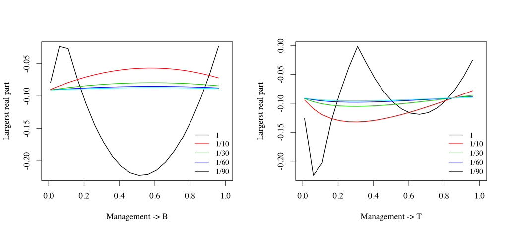

```r
par(mfrow = c(1, 2), family = "serif", cex = 1.2)
managSim(Par = c(1, 7))
managSim(Par = c(2, 7))
```

### Scenario 2: thinning + harvest + plantation

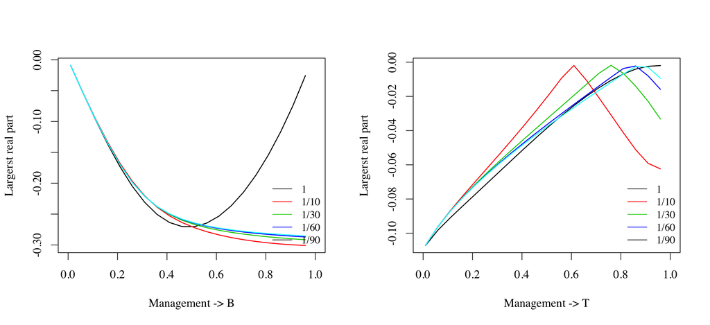

```r
par(mfrow = c(1, 2), family = "serif", cex = 1.2)
managSim(Par = c(1, 3, 5, 7))
managSim(Par = c(2, 4, 6, 7))
```